# Latihan ggplot 2

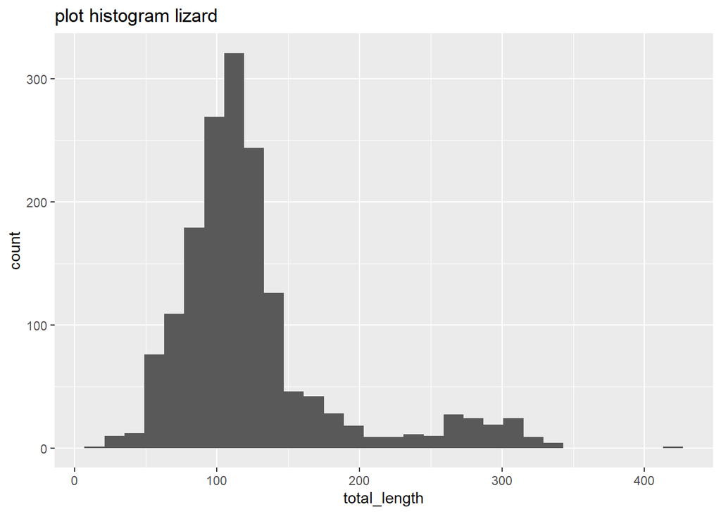

```r
ggplot(lizard,aes(x=total_length))+
  geom_histogram()+
  labs (title="plot histogram lizard",x="total_length")
```

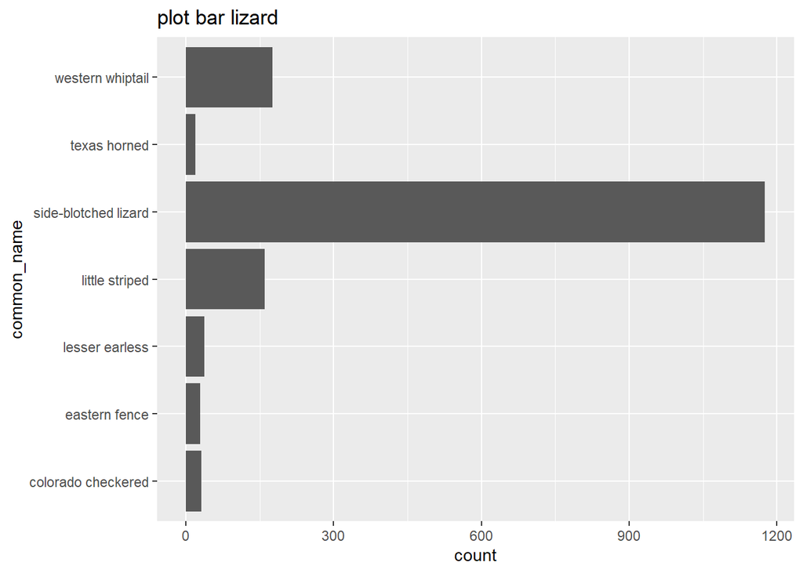

```r
ggplot(lizard,aes( y=common_name))+
  geom_bar()+
  labs (title="plot bar lizard",y="common_name")
```

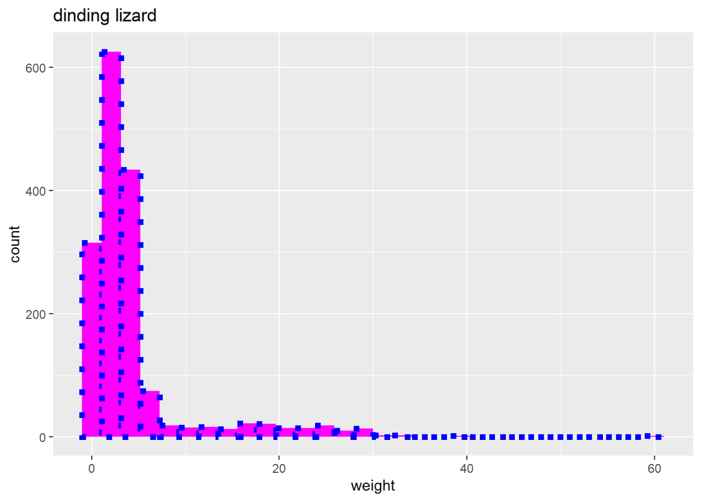

```r
ggplot(lizard,aes(x=weight))+
  geom_histogram(color = "blue",size = 2,shape = 16,fill = "magenta",linetype ="dotted")+
  labs (title="dinding lizard",x="weight",y = "count")
```

# 4. Read Data

Read data adalah proses membaca atau mengimpor data dari sumber external (seperti file atau database) ke dalam R untuk dianalisis. Data ini bisa berupa file spreadsheet, teks, CSV, JSON, atau bahkan database. Proses ini penting karena analisis data hanya bisa dilakukan setelah data berhasil dimasukkan ke dalam R.

## 4.1 Jenis File yang Bisa Dibaca di R

### 1.File CSV (Comma Separated Values)

CSV adalah format yang paling umum digunakan untuk menyimpan data. Setiap baris dalam file mewakili satu observasi, dan setiap nilai dipisahkan oleh tanda koma.

### 2.File Excel (XLS atau XLSX)

Data yang disimpan dalam file Excel sering digunakan dalam pekerjaan administratif atau akademik. File ini mendukung beberapa lembar kerja (worksheet).

### 3.File Teks (TXT)

File teks biasanya digunakan untuk data dengan pemisah khusus, seperti tab atau spasi.

### 4.File JSON (JavaScript Object Notation)

Format ini sering digunakan untuk data yang berasal dari API atau aplikasi berbasis web.

### 5.Database SQL

Jika data disimpan dalam database, Anda bisa mengaksesnya langsung dari R dengan koneksi ke database tersebut.

### 6.Sumber Data Online

R juga memungkinkan Anda membaca data langsung dari internet, seperti file CSV atau JSON yang tersedia melalui URL.

```r
library(gapminder)
library(ggplot2)
library(gganimate)
data=gapminder
data
```

| country | continent | year | lifeExp | pop | gdpPercap |
| --- | --- | --- | --- | --- | --- |
| Afghanistan | Asia | 1952 | 28.80100 | 8425333 | 779.4453 |
| Afghanistan | Asia | 1957 | 30.33200 | 9240934 | 820.8530 |
| Afghanistan | Asia | 1962 | 31.99700 | 10267083 | 853.1007 |
| Afghanistan | Asia | 1967 | 34.02000 | 11537966 | 836.1971 |
| Afghanistan | Asia | 1972 | 36.08800 | 13079460 | 739.9811 |
| Afghanistan | Asia | 1977 | 38.43800 | 14880372 | 786.1134 |
| Afghanistan | Asia | 1982 | 39.85400 | 12881816 | 978.0114 |
| Afghanistan | Asia | 1987 | 40.82200 | 13867957 | 852.3959 |
| Afghanistan | Asia | 1992 | 41.67400 | 16317921 | 649.3414 |
| Afghanistan | Asia | 1997 | 41.76300 | 22227415 | 635.3414 |

[output cut: 1694 more lines]

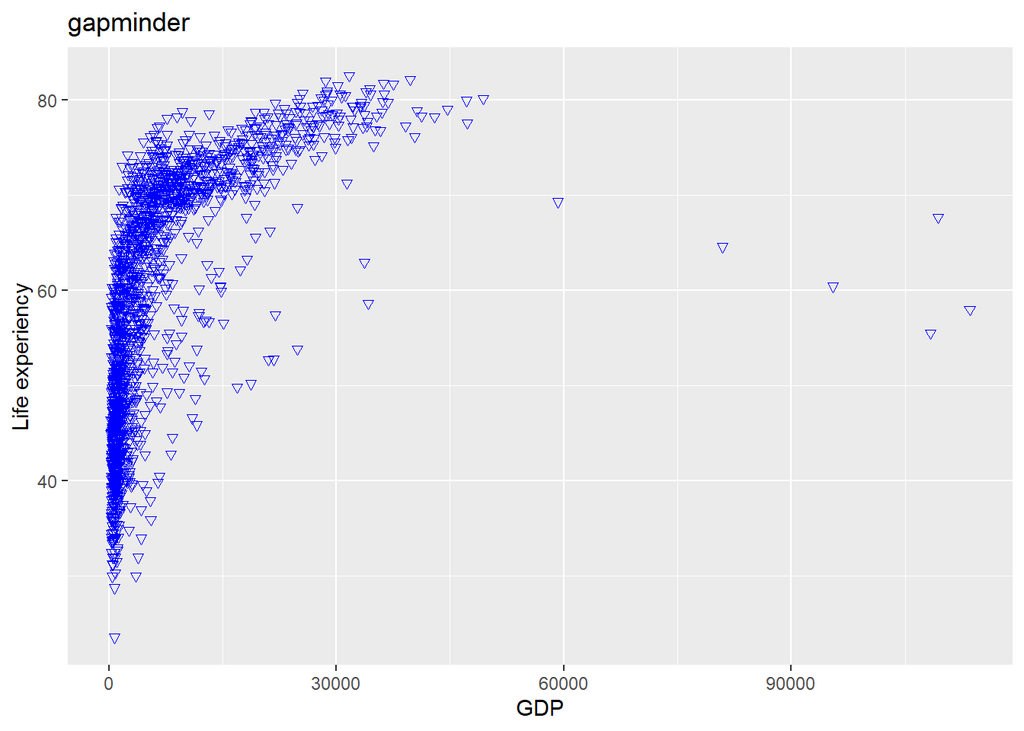

```r
ggplot(data, aes(x = gdpPercap, y = lifeExp)) + geom_point(shape = 6, color = "blue")+
  labs (title = "gapminder", x = "GDP", y = "Life experiency")
```

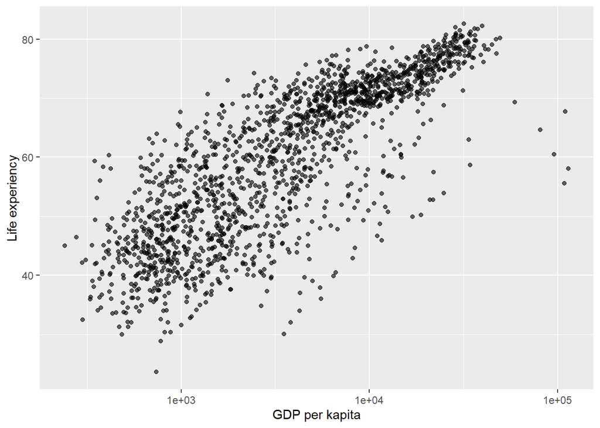

```r
gapminder_plot <- ggplot(
  gapminder,
  aes(x = gdpPercap, y = lifeExp)
)+
  geom_point(alpha= 0.6)+
  scale_x_log10()+
  labs(x = "GDP per kapita", y = "Life experiency")
gapminder_plot
```

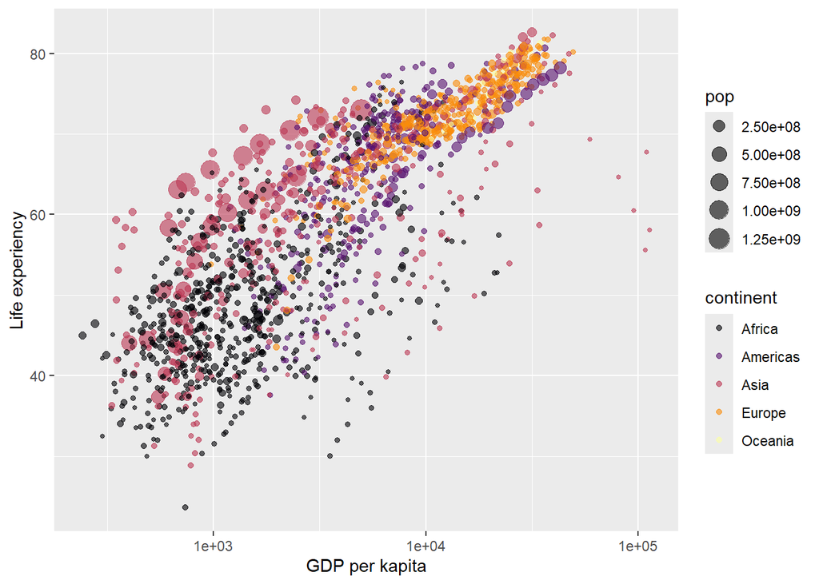

```r
gapminder_plot <- ggplot(
  gapminder,
  aes(x = gdpPercap, y = lifeExp,size = pop,color = continent)
)+
  geom_point(alpha= 0.6)+
  scale_x_log10()+
  scale_color_viridis_d(option = "inferno")+
  labs(x = "GDP per kapita", y = "Life experiency")
gapminder_plot
```